# Demography behind household sizes in Switzerland and its change in time

## Outline

This data study aims at analyzing how people live based on the number of people living per household in Switzerland. Do location, housing prize, income, demographic affiliation or even political orientation influence the number of people we are living with? Diverse Data provided by the Federal Statistical Office of Switzerland between 2010 and 2017 are analyzed on communal level. General trends are discovered and the spatial dependence analyzed. Shared households are very common in low-income societies, such as student-accommodations. How the effective household sizes are connected to the demographic informations and also the political opinion of regions will be investigated in the following.

We can formulate our principal research questions as follows:

**- Is there a correlation between the foreign population in Switzerland and the number of people living per household?**

**- Is there a correlation between the level of income and the size of the households?**

There can be various factors that might affect the outcome and hence need to be taken into account when investigating those two statements. The principle ones that we will investigate on are the income classes, the location and their demographic affilation.

## Households in Switzerland

Everyone has to live somewhere. We have the household distribution for each commune in Switzerland. Many possibilities are given, to analyze the sizes over the country. As some of our datasets are based on regional resolutions, we want to look at the clustering in regions.

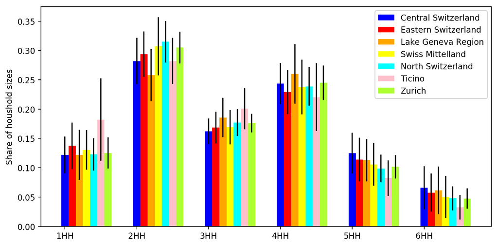

## Money and Incomes

Open access to personal data has always been a discrete topic, especially in Switzerland. Rising a topic about your fortune, incomes or other financial settings is not very popular in the discrete Swiss population. Hence, mean incomes data is not shared by the swiss federal office for statistics on a municipal level. Meanwhile, hidden on some computer of EPFL's Labs, a datafile with cryptic column names has been found which contains after further investigations the mean and median incomes on a communal resolution for the year 2007.

As we live in a dynamic world today, we do not care about old data. Luckily, mean wages are available on a regional scale for the years since 2008 on a two years frequency, which development is displayed below.

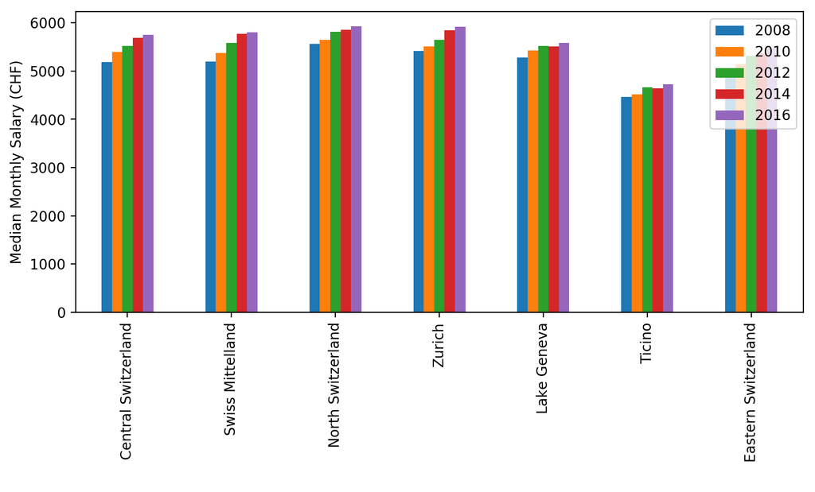

First of all, the incomes are distributed quiet unfair in Switzerland and a few rich people earn a lot more than others. For this reason the median income is regarded more representative as the average and therefore used in the following analysis. From the graph we can see, that the development of incomes in Switzerland is not equally distributed over the country. It might be impertinent to talk about poor regions in this country, but still remarkable differences exist. The Italian speaking region of Switzerland has always complained about being somewhat apart from the rest of the country. This seems also true for the median income. The other regions are more similar to each other, but still, the eastern part of Switzerland seems to fall a little behind in matter of income as well. The differences of the cantons and regions in Switzerland are remarkable, thinking about the very modest size of the country. The economic development in the years 2008-2016 differ from region to region. It seems that central Switzerland with its very attractive tax conditions attracts a population with elevated incomes, especially during the last years. This is also the case for the Mittelland. The French speaking part and the aforementioned two "poorer" regions could not show a comparable increase in mean incomes.

### Extrapolation

With the information above, we could extrapolate our “old” income data from 2007 up to 2016. For that we make the following assumptions

- We assume no change from 2007 to 2008, as the trends are only known from 2008
- A development for each two even years can be directly done from 2008 till 2016
- Take 2008 as reference year and calculate percent change to years 2010, 2012, 2014 and 2016
- Compare each commune with the trend in its region
- To fill even years, we take the average between the precedent and following year.

For the example of Lavertezzo, a small commune in Ticino, this would give:

$$ \mathrm{Lavertezzo_{2012, Ti}} = \mathrm{Lavertezzo_{2008, Ti} * \frac{Ticino_{2012}}{Ticino_{2008}}}$$

With this extrapolation method, we do not suffer from linearization bias and are able to follow the real development trend.

A problem that we face has its origin in another Swiss trend. To stop the so called federalism, small municipalities merged with others or were integrated in bigger ones. Like this, financial expenses can be saved. For us, it means, that each year does not have the same number of municipalities, as the fusions did not happen at one centralized date. This is not how Switzerland works. For us this means that we ‘lose’ some information as communes get lost through merging.

## Equality and Integration

Before going straight to the household size distribution, we detected a striking income gap between swiss and foreigner income population worth presenting.

Two million people in Switzerland's Population are not in possession of a Swiss pass. This is equal to a little more than 20 %. The Swiss system and politics take some measures to better integrate the new population into its society. Meanwhile, the plotted distribution of the mean incomes are not a proof of very efficient integration. The Swiss population suffers from a continous difference between the incomes of the Non-Swiss and Swiss people. The trends show a similar slope. Thus, the integrating population can follow the evolution, but not catch up with the mean incomes.

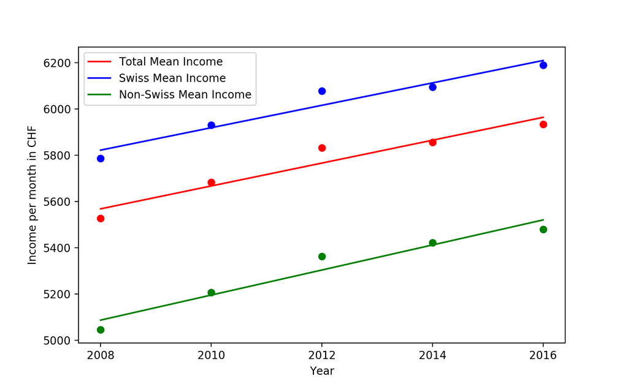

## Relation between Incomes and Household sizes

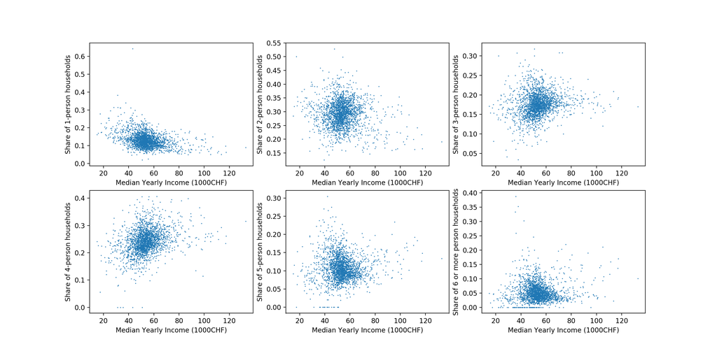

How about applying a pearson coefficient?

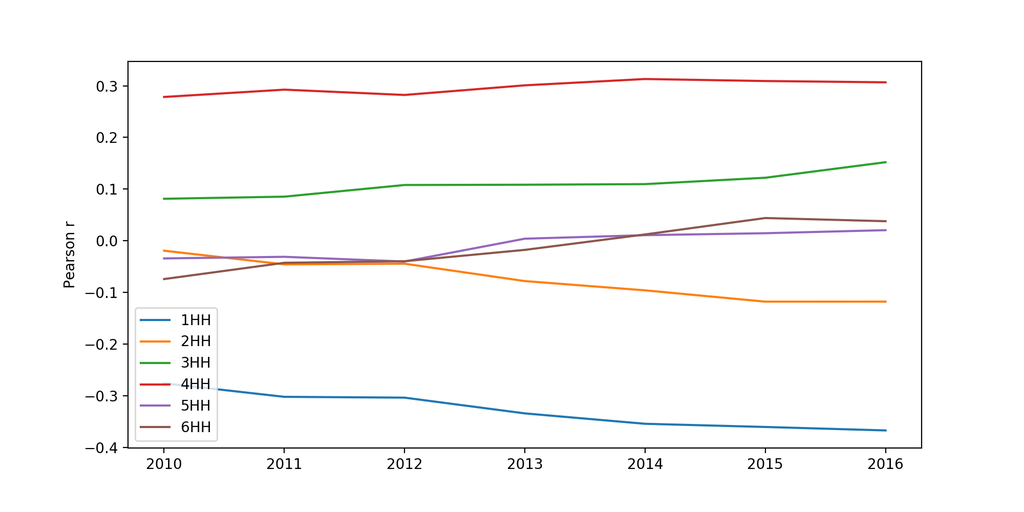

The pearson coefficients are plotted for all the available years. Thus, we observe the evolution of the correlation between median income and the household sizes.

The linear correlation coefficients stay more or less stable. The blue line indicates that in communes with higher average incomes, the share of people living alone is smaller, aka there is a weak negative correlation. For 4-person households it is the opposite. This indicates that in communes with higher average incomes, there are relatively more 4-person households. The p-value of these two correlations (1HH and 4HH) are very small, indicating a statistically highy significance of the correlations. This makes sense, as 4-person households are likely to be families, with a high income. whereas people living alone are more likely to be pensioners or mid-ages(25-40). For the other household sizes, there is almost no correlation detectable.

## Relation between share of Non-Swiss Population and Household size

We also want to exploit the other demographic data that we have for the municipalities of Switzerland. Compared to financial data about the people, the resolution of other information is much better and the values more precise. We do not have to extrapolate from some year, but can directly apply a comprehensive file from 2016.

Put together with the household sizes, we select some intersting variables and look at their covariances. Special interest is given to the share of Non-Swiss inhabitants, as we are interested in this relation to the respecively dominant household sizes. For this purpose, a classical heatmap represents a good visualization. It allows us to see the covariance matrix of our dataframe in a colourfol image.

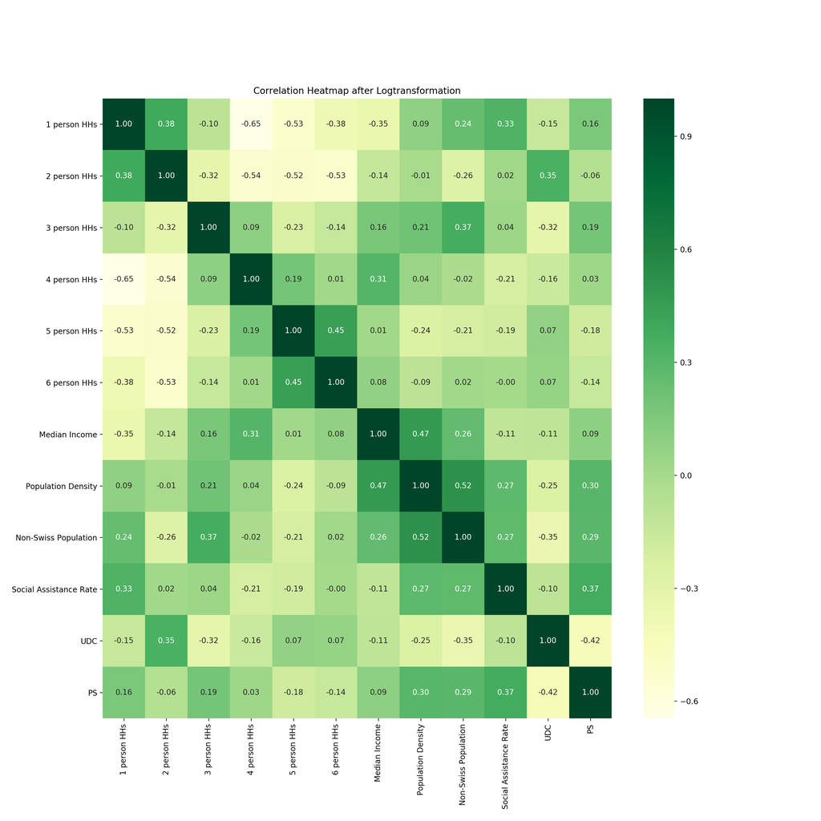

## Some fun statements

**But before! Attention:** Please regard these correlations with caution as it is a linear descriptor and does only represent correlation and NOT causality. There might be many other factors influencing our variables. We regard |r-values| > 0.2 as having a correlation(weak but present). The calculated p-values of these correlations are all well below 0.01, indicating a high statistical significance. However, the fact that there are many communes(objects), influences this result of the p-values. Even though it is not scientifically correct, for a data-story as this one here, we regard it to be fun to present some informal statements. The correct interpretation of the the following statements would be for example:“Communes with higher median income are more likely to have a higher share of 4-person households”. By saying family below we already give our interpretation.

- Richer people are more likely to live in families (4HH)
- Foreigners are more likely to live alone or in 3-person households
- UDC-voters tend to live in 2 person households

Beside that: “The stereotype UDC-voter (right-wing) lives in rural (low-population density) commune with low foreigner rate “

And even more correlations:

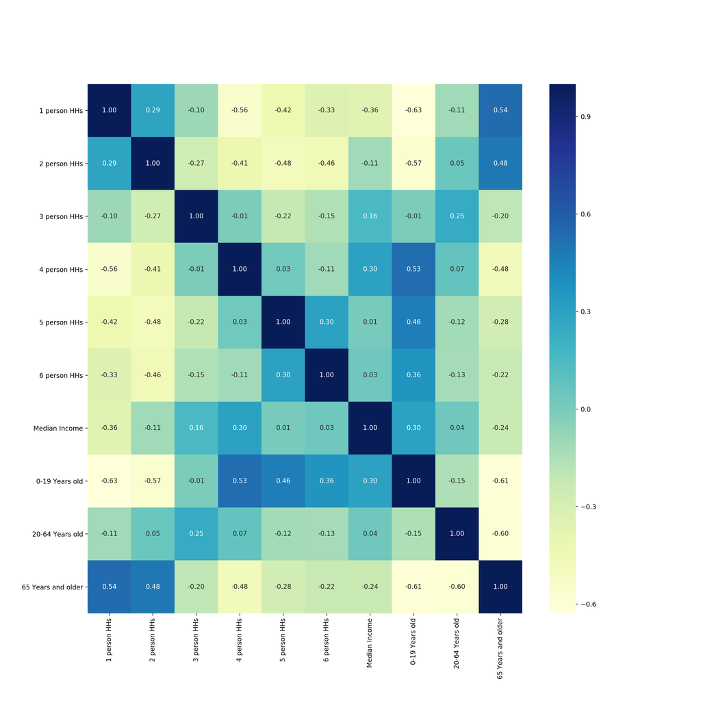

**Facts from the Heatmap**

- Kids and teenagers live in families (4hh,5hh,6+hh), which are more likely to live in a higher income community
- Retired persons mostly live alone or in couples

## Interactive Swiss Map

For a good visualization aspect of the demographics of Switzerland, we have created an interactive Map. It does only display information about the cantons and their population, but still draws some interesting features.

Feel free to explore Switzerland! Be aware, that the html-file "swiss_map.html" has to be in the same folder as this project html.

Swiss Interactive Map

## Machine Learning: Your Household size Predictor!

What if. What if we search a new place to live in Switzerland, but we know nothing about the household size to be expected. What we know is our monthly income, nationality and where we want to live. This predictor can tell us, in what household size we will live afterwards.

The given data is large enough to provide a training set for a machine learning algorithm. The goal is to predict the household size one will live in based on the following features of the person:

- Swiss or Foreign: binary (Swiss= 1, Foreign = 0)
- Income: integer of monthly income
- Region: integer from 1 to 7
  - central = 1
  - east = 2
  - lake_ge = 3
  - mittelland = 4
  - north = 5
  - ti = 6
  - zh = 7

The dataset is taken from the year of 2016, and includes the following features per commune for each household size:

- Population density per square km
- Number of households
- Average household size
- Income: income is dependent on whether the person is Swiss or Foreign
- Population: population depending on either Swiss or Non-Swiss identity
- Swiss: binary value for Swiss or Non-Swiss nationality
- Region: Classification with Integer

The dataset is then split into train and test set for features and labels, where the labels are household sizes ranging from 1 to 6, corresponding to the household size. There is a total of 25,632 rows in the data. A Random Forest Classifier is used for prediction. A Grid Search with a 5-fold cross validation is used to determine the best parameters to determine the n_estimators and the max_depth of the Random Forest. The following best parameters were determined:

- n_estimators: 100
- max_depth: 10

Based on the pest parameters given, the accuracy was tested with the test set which was previously separated from the dataset using train_test_split. The accuracy given was only around 35%.

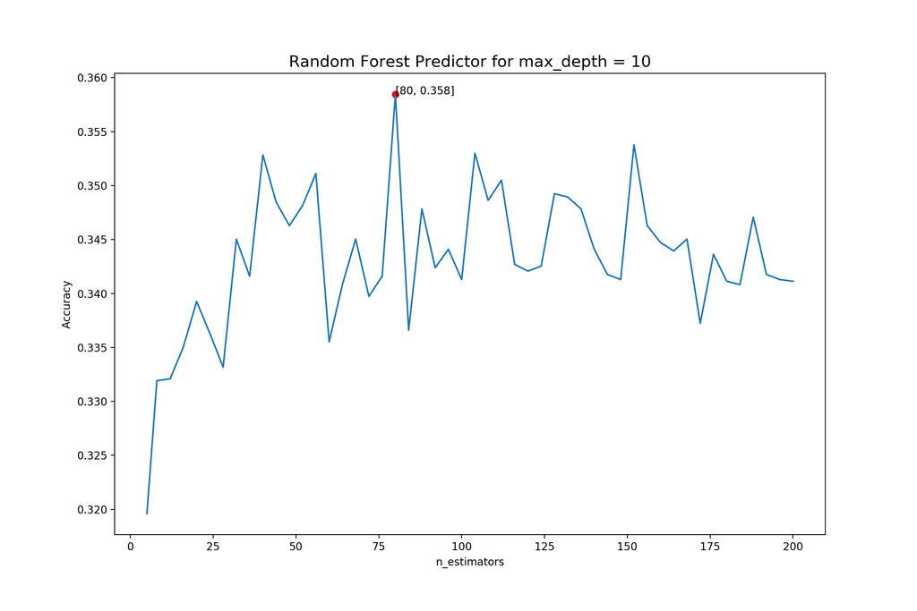

As the best parameters are provided by the Grid Search, the graph displays the variation of the accuracy depending on the n_estimators between 1 and 200, keeping the max_depth = 10. The highest accuracy is displayed at **80 n_estimators**, with an **accuracy of 35.8%**.

Given that only income, citizenship, and region is being changed for the prediction, to fill the values for the other features, it was determined to take the average value for the corresponding dataset. For example, if citizenship is set to Swiss, and the region is set to central, then the average values are taken for each feature where the dataset is within the region provided and the corresponding citizenship.

More specific examples are the following:

- A person with citizenship Swiss, income of CHF 4000.-, living in the Lake Geneva region. The predictor displays that the person will live in a 1-person household.
- A person with citizenship Foreign, with the same income and living in the same region, will, according to the prediction, live in a 2-person household.
- A person with citizenship Swiss, income of CHF 3000.-, living in the Zurich region. The predictor displays that the person will live in a 2-person household.
- A person with citizenship Foreign, with the same income and living in the same region, will, according to the prediction, live in a 3-person household.
- A person with citizenship Swiss, income of CHF 6000.-, living in the North region. The predictor displays that the person will live in a 3-person household.
- A person with citizenship Foreign, with the same income and living in the same region, will, according to the prediction, live in a 4-person household.
- A person with citizenship Swiss, income of CHF 2000.-, living in the Mittelland region. The predictor displays that the person will live in a 4-person household.
- A person with citizenship Foreign, with the same income and living in the same region, will, according to the prediction, live in a 4-person household, as well.

## Summary

A huge amount of data allows for thousands of interesting analysis. We focused on our research questions and answered those, but many other things have caught our eyes and were investigated. The most interesting part finds place in this document, but many others are listed in the projects notebook.

We hope you learnt new things about this country, we certainly did!

### References

*[1]:https://www.srf.ch/news/panorama/drei-megatrends-veraendern-das-wohnen*  
*[2]:https://www.beobachter.ch/wohnen/miete/wohnverhalten-die-bleibe-der-zukunft*